# PCA_ejemplo1

```python
import numpy as np
import matplotlib.pyplot as plt
from sklearn.decomposition import PCA
```

### PCA para visualization: digitos manuscritos

La utilidad de la reducción de la dimensionalidad puede no ser del todo evidente en solo dos dimensiones, pero se vuelve mucho más clara cuando se observan datos de alta dimensión.

Comenzamos cargando los datos:

```python
from sklearn.datasets import load_digits
digits = load_digits()
digits.data.shape
```

```
(1797, 64)
```

Recuerde que los datos consisten en imágenes de 8 × 8 píxeles, lo que significa que son de 64 dimensiones. Para ganar algo de intuición en las relaciones entre estos puntos, podemos usar PCA para proyectarlos a un número de dimensiones más manejable, digamos dos:

```python
pca = PCA(2)  # proyectar de 64 a 2 dimensiones
projected = pca.fit_transform(digits.data)
print(digits.data.shape)
print(projected.shape)
```

```
(1797, 64)
(1797, 2)
```

Ahora podemos trazar los dos primeros componentes principales de cada punto para aprender sobre los datos:

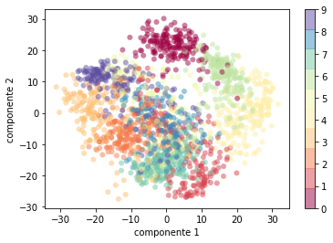

```python
plt.scatter(projected[:, 0], projected[:, 1],
            c=digits.target, edgecolor='none', alpha=0.5,
            cmap=plt.cm.get_cmap('Spectral', 10))
plt.xlabel('componente 1')
plt.ylabel('componente 2')
plt.colorbar();
```

Recuerde lo que significan estos componentes: los datos completos son una nube de puntos de 64 dimensiones, y estos puntos son la proyección de cada punto de datos a lo largo de las direcciones con la mayor varianza. Esencialmente, hemos encontrado el estiramiento y la rotación óptimos en el espacio de 64 dimensiones que nos permite ver el diseño de los dígitos en dos dimensiones, y lo hemos hecho de manera no supervisada, es decir, sin referencia a las etiquetas.

### ¿Qué significan los componentes?

Podemos ir un poco más lejos aquí y comenzar a preguntar qué significan las dimensiones reducidas *. Este significado se puede entender en términos de combinaciones de vectores de base. Por ejemplo, cada imagen en el conjunto de entrenamiento está definida por una colección de valores de 64 píxeles, que llamaremos el vector $x$:

$$ x = [x_1, x_2, x_3 \cdots x_{64}] $$

Una forma en que podemos pensar esto es en términos de una base de píxeles. Es decir, para construir la imagen, multiplicamos cada elemento del vector por el píxel que describe, y luego sumamos los resultados para construir la imagen:

$$ {\rm image}(x) = x_1 \cdot{\rm (pixel~1)} + x_2 \cdot{\rm (pixel~2)} + x_3 \cdot{\rm (pixel~3)} \cdots x_{64} \cdot{\rm (pixel~64)} $$

Una forma que podríamos imaginar al reducir la dimensión de estos datos es poner a cero todos, excepto algunos de estos vectores básicos. Por ejemplo, si usamos solo los primeros ocho píxeles, obtendremos una proyección en ocho dimensiones de los datos, pero no refleja mucho la imagen completa: ¡hemos eliminado casi el 90% de los píxeles!

[figure not shown]

figure source in Appendix

La fila superior de paneles muestra los píxeles individuales, y la fila inferior muestra la contribución acumulada de estos píxeles a la construcción de la imagen. Usando solo ocho de los componentes basados en píxeles, solo podemos construir una pequeña porción de la imagen de 64 píxeles. Si continuáramos esta secuencia y usáramos los 64 píxeles, recuperaríamos la imagen original.

Pero la representación de píxeles no es la única opción de base. También podemos usar otras funciones básicas, cada una de las cuales contiene una contribución predefinida de cada píxel, y escribir algo así como

$$ image(x) = {\rm mean} + x_1 \cdot{\rm (basis~1)} + x_2 \cdot{\rm (basis~2)} + x_3 \cdot{\rm (basis~3)} \cdots $$

Se puede pensar en la PCA como un proceso de selección de funciones de base óptima, de manera que sumar solo las primeras pocas de ellas es suficiente para reconstruir adecuadamente la mayor parte de los elementos en el conjunto de datos. Los componentes principales, que actúan como la representación de baja dimensión de nuestros datos, son simplemente los coeficientes que multiplican cada uno de los elementos de esta serie. Esta figura muestra una representación similar de la reconstrucción de este dígito utilizando la media más las primeras ocho funciones básicas de PCA:

[figure not shown]

figure source in Appendix

A diferencia de la base de píxeles, la base de PCA nos permite recuperar las características más destacadas de la imagen de entrada con solo una media más ocho componentes. La cantidad de cada píxel en cada componente es el corolario de la orientación del vector en nuestro ejemplo bidimensional. Este es el sentido en el que PCA proporciona una representación de baja dimensión de los datos: descubre un conjunto de funciones básicas que son más eficientes que la base de píxeles nativa de los datos de entrada.

### Elegir el número de componentes

Una parte vital del uso de PCA en la práctica es la capacidad de estimar cuántos componentes se necesitan para describir los datos. Esto puede determinarse observando la relación de varianza explicada *acumulada* como una función del número de componentes:

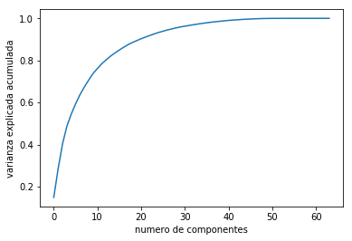

```python
pca = PCA().fit(digits.data)
plt.plot(np.cumsum(pca.explained_variance_ratio_))
plt.xlabel('numero de componentes')
plt.ylabel('varianza explicada acumulada');
```

Esta curva cuantifica cuánto de la varianza total de 64 dimensiones está contenida dentro de los primeros componentes de $N$. Por ejemplo, vemos que con los dígitos los primeros 10 componentes contienen aproximadamente el 75% de la varianza, mientras que se necesitan alrededor de 50 componentes para describir cerca del 100% de la varianza.

Aquí vemos que nuestra proyección bidimensional pierde mucha información (medida por la varianza explicada) y que necesitaríamos unos 20 componentes para retener el 90% de la varianza. Ver esta gráfica para un conjunto de datos de alta dimensión puede ayudarlo a comprender el nivel de redundancia presente en múltiples observaciones.

## PCA como filtrado de ruido

PCA también se puede utilizar como un enfoque de filtrado para datos ruidosos. La idea es esta: cualquier componente con una variación mucho mayor que el efecto del ruido no debería verse afectado por el ruido. Por lo tanto, si reconstruye los datos utilizando solo el subconjunto más grande de componentes principales, debe mantener preferencialmente la señal y eliminar el ruido.

Veamos cómo se ve esto con los datos de los dígitos. Primero trazaremos varios de los datos de entrada sin ruido:

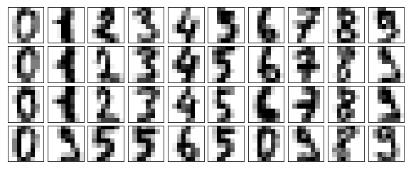

```python
def plot_digits(data):
    fig, axes = plt.subplots(4, 10, figsize=(10, 4),
                             subplot_kw={'xticks':[], 'yticks':[]},
                             gridspec_kw=dict(hspace=0.1, wspace=0.1))
    for i, ax in enumerate(axes.flat):
        ax.imshow(data[i].reshape(8, 8),
                  cmap='binary', interpolation='nearest',
                  clim=(0, 16))
plot_digits(digits.data)
```

Ahora agreguemos un poco de ruido aleatorio para crear un conjunto de datos ruidoso y vuelva a trazarlo:

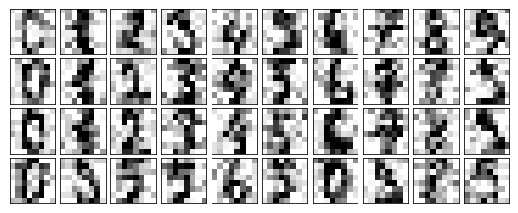

```python
np.random.seed(42)
noisy = np.random.normal(digits.data, 4)
plot_digits(noisy)
```

Está claro a simple vista que las imágenes son ruidosas y contienen píxeles espurios. Entrenemos un PCA en los datos ruidosos, solicitando que la proyección conserve el 50% de la varianza:

```python
pca = PCA(0.50).fit(noisy)
pca.n_components_
```

```
12
```

Aquí el 50% de la varianza equivale a 12 componentes principales. Ahora calculamos estos componentes y luego usamos la inversa de la transformación para reconstruir los dígitos filtrados:

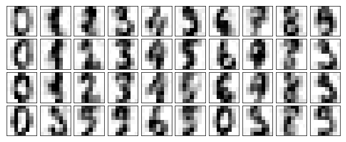

```python
components = pca.transform(noisy)
filtered = pca.inverse_transform(components)
plot_digits(filtered)
```

Esta propiedad de preservación de señal / filtro de ruido hace de la PCA una rutina de selección de características muy útil; por ejemplo, en lugar de entrenar a un clasificador en datos de muy alta dimensión, puede entrenar al clasificador en la representación de dimensiones inferiores, que servirá automáticamente para filtrar Fuera ruido aleatorio en las entradas.